# Project 5

Creating data from digital sources

Amy Li

## Part A

The data context I chose to explore was the different prices and makeup products on the website Hikoco.

I selected this data context as I am a frequent customer of Hikoco, and I am very interested in knowing which products are available as well as comparing the prices, brands and reviews. I was excited to explore the data in order to make more informed decisions about purchases.

```r
library(rvest)
library(tidyverse)

# My data context is the different products on Hikoco, compared with each other according to price and number of reviews.

hikoco_makeup <- "/collections/makeup"

url <- paste0("https://hikoco.co.nz", hikoco_makeup)

page <- read_html(url)

# the product name
makeup_title <- page %>%
  html_elements(".grid-product__title") %>%
  html_text2()

# brand name
brand_title <- page %>%
  html_elements(".grid-product__vendor") %>%
  html_text2()

# price
makeup_prices <- page %>%
  html_elements(".grid-product__price--current") %>%
  html_text2()

# number of reviews
review_numbers <- page %>%
  html_elements(".jdgm-prev-badge__text") %>%
  html_text2()

makeup_title
```

```
##  [1] "Pore Fresh Deep Cleansing Bubble Mask Set [5 Masks]"
##  [2] "Artclass Frottage Pencil [#11 Dew Beige]"
##  [3] "Relief Sun: Rice + Probiotics SPF50+ Broad Spectrum"
##  [4] "Matcha Biome Amino Acne Cleansing Foam"
##  [5] "Snail Repairing Foam Cleanser"
##  [6] "Supple Preparation Unscented Toner"
##  [7] "Midnight Blue Calming Cream"
##  [8] "Semi-Cured Gel Nail [#N Memory]"
##  [9] "Glasting Melting Balm [#09 Peonies]"
## [10] "Artclass Frottage Pencil [#11 Dew Beige]"
## [11] "Artclass Frottage Pencil [#09 Sheer Nude]"
## [12] "Artclass Frottage Pencil [#01 Shining Linen]"
## [13] "All Take Mood Palette [#17 Hip Grey]"
## [14] "Superproof Pen Liner [Kill Brown]"
## [15] "Pure Blushed Custom Cheek [#03 Soul Rose]"
```

[output cut: 42 more lines]

```r
brand_title
```

```
##  [1] "Mizon"               "Too Cool for School" "Beauty of Joseon"
##  [4] "Heimish"             "Mizon"               "Klairs"
##  [7] "Klairs"              "Ohora"               "Rom&nd"
## [10] "Too Cool for School" "Too Cool for School" "Too Cool for School"
## [13] "Peripera"            "Clio"                "Peripera"
## [16] "Peripera"            "Peripera"            "Peripera"
## [19] "Peripera"            "Peripera"            "Peripera"
## [22] "Heimish"             "Heimish"             "Heimish"
## [25] "Heimish"             "Etude"               "Etude"
## [28] "Etude"               "Tirtir"              "Tirtir"
## [31] "Tirtir"              "Tirtir"              "Tirtir"
## [34] "Tirtir"              "Tocobo"              "Tirtir"
## [37] "Tirtir"              "Tirtir"              "Peripera"
## [40] "Peripera"            "Peripera"            "Too Cool for School"
## [43] "Lilybyred"           "Lilybyred"           "Lilybyred"
## [46] "Lilybyred"           "Lilybyred"           "Lilybyred"
## [49] "Lilybyred"           "Lilybyred"           "Lilybyred"
## [52] "Lilybyred"           "Lilybyred"           "Lilybyred"
## [55] "Peripera"            "Peripera"            "Peripera"
```

```r
makeup_prices
```

```
##  [1] "$2000 $20.00" "$2400 $24.00" "$2800 $28.00" "$1900 $19.00" "$1300 $13.00"
##  [6] "$3400 $34.00" "$4000 $40.00" "$2700 $27.00" "$1900 $19.00" "$2400 $24.00"
## [11] "$2400 $24.00" "$2400 $24.00" "$3500 $35.00" "$2800 $28.00" "$1700 $17.00"
## [16] "$1700 $17.00" "$1700 $17.00" "$2200 $22.00" "$2200 $22.00" "$2200 $22.00"
## [21] "$4500 $45.00" "$3100 $31.00" "$3100 $31.00" "$3100 $31.00" "$3100 $31.00"
## [26] "$2800 $28.00" "$1400 $14.00" "$1400 $14.00" "$4500 $45.00" "$4500 $45.00"
## [31] "$4500 $45.00" "$4500 $45.00" "$4500 $45.00" "$4500 $45.00" "$2700 $27.00"
## [36] "$4500 $45.00" "$4500 $45.00" "$4500 $45.00" "$4100 $41.00" "$4100 $41.00"
## [41] "$4100 $41.00" "$2900 $29.00" "$2100 $21.00" "$2100 $21.00" "$2100 $21.00"
## [46] "$2100 $21.00" "$2100 $21.00" "$2100 $21.00" "$2100 $21.00" "$2100 $21.00"
## [51] "$2100 $21.00" "$2100 $21.00" "$2500 $25.00" "$2500 $25.00" "$1500 $15.00"
## [56] "$1500 $15.00" "$1500 $15.00"
```

```r
review_numbers
```

```
##  [1] "No reviews"  "No reviews"  "373 reviews" "8 reviews"   "16 reviews"
##  [6] "48 reviews"  "62 reviews"  "2 reviews"   "3 reviews"   "No reviews"
## [11] "No reviews"  "No reviews"  "No reviews"  "No reviews"  "No reviews"
## [16] "No reviews"  "No reviews"  "No reviews"  "No reviews"  "No reviews"
## [21] "No reviews"  "No reviews"  "No reviews"  "No reviews"  "No reviews"
## [26] "No reviews"  "No reviews"  "No reviews"  "No reviews"  "No reviews"
## [31] "1 review"    "1 review"    "No reviews"  "No reviews"  "2 reviews"
## [36] "7 reviews"   "4 reviews"   "4 reviews"   "1 review"    "No reviews"
## [41] "No reviews"  "1 review"    "No reviews"  "1 review"    "No reviews"
## [46] "No reviews"  "No reviews"  "No reviews"  "1 review"    "1 review"
## [51] "No reviews"  "1 review"    "1 review"    "No reviews"  "No reviews"
## [56] "1 review"    "1 review"
```

## Part B

```r
library(rvest)
library(tidyverse)

# The minister I chose was Hon Brooke van Velden

# Hon Brooke van Velden's releases are not usually very long, and the terminology used is not too difficult to understand, however is quite formal. There is no other punctuation used apart from periods and quotation marks. She often uses words such as 'we' instead of personal pronouns. Usually a paragraph is around 40 to 50 words.

url <- "https://www.beehive.govt.nz/minister/hon-brooke-van-velden"

pages <- read_html(url) %>%
  html_elements(".release__wrapper") %>%
  html_elements("h2") %>%
  html_elements("a") %>%
  html_attr("href") %>%
  paste0("https://www.beehive.govt.nz", .)

# HTML info for title: h1, article__title. info for content: p

page_url <- pages[1]

page <- read_html(page_url)

release_title <- page %>%
  html_elements("h1") %>%
  html_text2

release_content <- page %>%
  html_elements(".prose.field.field--name-body.field--type-text-with-summary.field--label-hidden.field--item") %>%
  html_text2

get_release <- function(page_url){
  Sys.sleep(2)
  # print the page_url so if things go wrong
  # we can see which page caused issues
  print(page_url)
  page <- read_html(page_url)

  # add code to scrape the release title and release content
  release_title <- page %>%
    html_elements("h1") %>%
    html_text2

  release_content <- page %>%
    html_elements(".prose.field.field--name-body.field--type-text-with-summary.field--label-hidden.field--item") %>%
    html_text2

  # add code to return a tibble created using these data objects
  data <- tibble(release_title, release_content)
}
release_data <- map_df(pages, get_release)

release_data

# no punctuation, capitals

release_data <- release_data %>%
  mutate(release_no_punct = release_content %>%
           str_remove_all("[[:punct:]]"))

release_data <- release_data %>%
  mutate(release_lower = str_to_lower(release_no_punct))

# number of characters in release content

release_data <- release_data %>%
  mutate(char_count = nchar(release_lower))

average_char_per_release <- release_data %>%
  group_by(release_lower) %>%
  summarise(avg_chars = mean(char_count))

overall_avg_chars <- release_data %>%
  summarise(overall_avg_chars = mean(char_count))

overall_avg_chars

# max and min words

word_data <- release_data %>%
  mutate(num_words = str_count(release_lower, "\\S+"))

max_word_title <- word_data %>%
  arrange(desc(num_words)) %>%
  slice(1) %>%
  pull(release_title)

min_word_title <- word_data %>%
  arrange(num_words) %>%
  slice(1) %>%
  pull(release_title)

# average number of words overall

word_data %>%
  group_by(release_lower) %>%
  summarise(mean_num_words = mean(num_words))

overall_avg_word <- word_data %>%
  summarise(overall_avg = mean(num_words)) %>%
  round(2)

print(overall_avg_word)

# sum of 'we' used and average

word_data <- word_data %>%
  mutate(we_used = str_count(release_lower, "we"))

overall_num_we <- word_data %>%
  summarise(overall_num = sum(we_used))

overall_avg_we <- word_data %>%
  summarise(overall_avg_we = mean(we_used))
```

The overall average number of characters in each release was 2783.25 characters.

The title release that had the most words used was “Speech to Auckland Business Chamber”, and title release that had the least amount of words used was “COVID-19 inquiry attracts 11,000 submissions”.

The average number of words overall was 459.83 words.

The number of times ‘we’ was used in every release was 78 times, and the average number of times ‘we’ was used in each release was 6.5 times.

## Part C

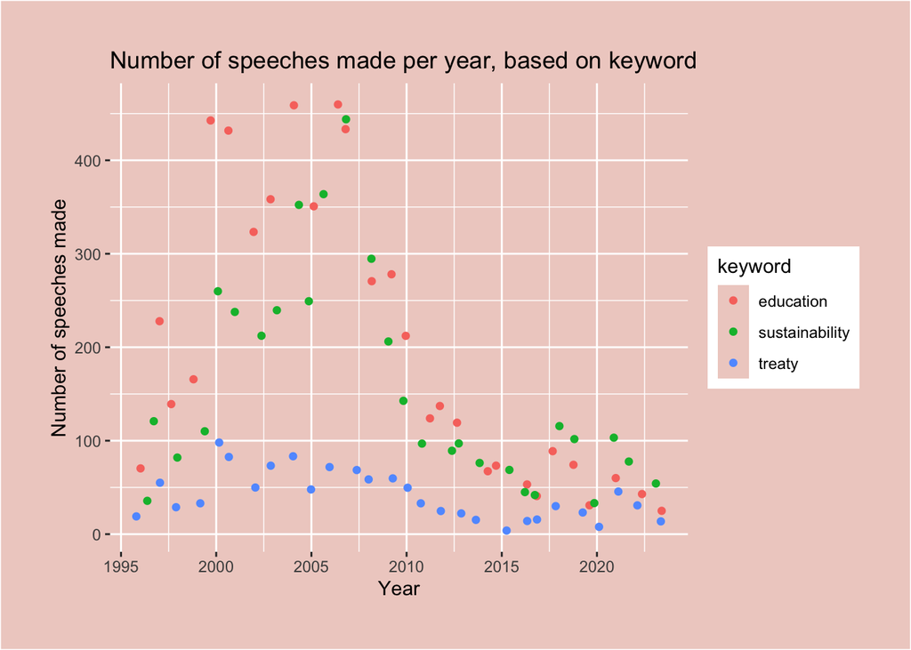

```r
library(tidyverse)
library(rvest)

# choosing keywords

keywords <- c("education", "sustainability", "treaty")

# creating searches

search1 <- read_html(paste0("https://datalandscapes.online/scrapeable/speeches.php?search=", keywords[1])) %>%
  html_elements(".speech_summary") %>%
  html_text2() %>%
  tibble(keyword = keywords[1],
         results = .) %>%
  separate(results, into = c("year", "num_speeches"), sep = "--") %>%
  mutate(num_speeches = parse_number(num_speeches),
         year = parse_number(year))

search2 <- read_html(paste0("https://datalandscapes.online/scrapeable/speeches.php?search=", keywords[2])) %>%
  html_elements(".speech_summary") %>%
  html_text2() %>%
  tibble(keyword = keywords[2],
         results = .) %>%
  separate(results, into = c("year", "num_speeches"), sep = "--") %>%
  mutate(num_speeches = parse_number(num_speeches),
         year = parse_number(year))

search3 <- read_html(paste0("https://datalandscapes.online/scrapeable/speeches.php?search=", keywords[3])) %>%
  html_elements(".speech_summary") %>%
  html_text2() %>%
  tibble(keyword = keywords[3],
         results = .) %>%
  separate(results, into = c("year", "num_speeches"), sep = "--") %>%
  mutate(num_speeches = parse_number(num_speeches),
         year = parse_number(year))

# creating combined data frame

combined_search <- bind_rows(search1, search2, search3)

csv_url <- "https://docs.google.com/spreadsheets/d/e/2PACX-1vRHTFJcFmsIkjaFUCEwFWASaBOAR4X2Upx66C5Bhgc_WNc2JxxdRbbvyoewmvt_EjNdCNZZzzkENwLg/pub?gid=0&single=true&output=csv"

speeches_government <- read_csv(csv_url)

speech_data <- left_join(combined_search, speeches_government, by = "year")

# creating graph

# colours and themes

my_colours <- c("#EFD0CA", "#C1BCAC", "#979B8D", "#5C7457", "#214E34")

my_theme <- theme(plot.background = element_rect(fill = my_colours[1]),
                  panel.background = element_rect(fill = my_colours[1]),
                  plot.margin = margin(1, 1, 1, 1, "cm"))

# creating plot

keyword_plot <- speech_data %>%
  ggplot() + geom_jitter(aes(x = year,
                  y = num_speeches,
                  colour = keyword),
              height = 0.4) +
  labs(title = "Number of speeches made per year, based on keyword",
       x = "Year",
       y = "Number of speeches made",
       colour = "keyword") +
  my_theme

print(keyword_plot)
```

One thing I learnt from my visualisation was that there is a huge discrepancy between words such as education and sustainability, to the word treaty. This is interesting considering the importance of the recognition of the Treaty in Aotearoa.

## Learning reflection

The most important idea I have learnt from Module 5 is the aspect of web-scraping and practising ethical methods of sourcing different data. I had some trouble at first trying to differentiate elements, however after practicing it more I was able to scrape data from Hikoco website. Now I am able to find the html element from the website, and find the data from the elements instead of pre-existing databases. In the future I want to know how I can manipulate the data after extracting it. I am also interested in becoming better at layering graphs on each other and knowing how data should be visualised.

## Self review

Two key skills that I have developed within my projects is the ability to communicate data and reporting with R markdown. I am able to code an HTML page through the use of R Markdown, and use CSS to personalise my report so that it looks presentable and cohesive. I have also learnt how to import data, and use R to create different visualisations for decision making. Another example of this is that I learnt different ways of wrangling of data in R to create a range of summary values, useful for analysing data and for decision making. Within visualisations, I have developed the skills to be able to customise the graph in R which was something that I was looking forward to learning.